# Bayesian Classification of Pediatric Appendicitis

Probability estimation, diagnostic uncertainty, and classification costs

Josh Boehm, Sinead MacFhionnlaoich, and Milan Grewal

## 1. Scientific Question and Data

```r
set.seed(638)

raw <- read.csv(
  "app_data.csv",
  na.strings = c("", "NA"),
  stringsAsFactors = FALSE,
  check.names = FALSE,
  fileEncoding = "UTF-8"
)

names(raw) <- make.names(sub("^\ufeff", "", names(raw)))

# trim text and treat entries with only spaces as missing
raw[] <- lapply(raw, function(x) {
  if (is.character(x)) {
    x <- trimws(x)
    x[x == ""] <- NA_character_
  }
  x
})

required_columns <- c(
  "Diagnosis", "Age", "Sex", "Body_Temperature", "WBC_Count", "CRP",
  "Lower_Right_Abd_Pain", "Migratory_Pain", "Nausea",
  "Appendix_on_US", "Free_Fluids", "Management", "Diagnosis_Presumptive"
)

missing_columns <- setdiff(required_columns, names(raw))
if (length(missing_columns) > 0) {
  stop("Missing required columns: ", paste(missing_columns, collapse = ", "))
}

stopifnot(nrow(raw) == 782L)

# stop if a label differs from what we expect
check_labels <- function(x, allowed, variable) {
  unexpected <- setdiff(unique(x[!is.na(x)]), allowed)
  if (length(unexpected) > 0) {
    stop(
      "Unexpected labels in ", variable, ": ",
      paste(unexpected, collapse = ", ")
    )
  }
}

check_labels(raw$Diagnosis, c("appendicitis", "no appendicitis"), "Diagnosis")
check_labels(raw$Sex, c("female", "male"), "Sex")

binary_variables <- c(
  "Lower_Right_Abd_Pain", "Migratory_Pain", "Nausea",
  "Appendix_on_US", "Free_Fluids"
)

for (v in binary_variables) {
  raw[[v]] <- tolower(raw[[v]])
  check_labels(raw[[v]], c("yes", "no"), v)
}

surgical_labels <- c(
  "primary surgical",
  "secondary surgical",
  "simultaneous appendectomy"
)

check_labels(
  raw$Management,
  c("conservative", surgical_labels),
  "Management"
)

# check numeric values before transforming them or fitting the model
numeric_variables <- c("Age", "Body_Temperature", "WBC_Count", "CRP")

for (v in numeric_variables) {
  if (!is.numeric(raw[[v]])) {
    stop(v, " must be numeric.")
  }
  if (any(!is.finite(raw[[v]]) & !is.na(raw[[v]]))) {
    stop(v, " contains non-finite values.")
  }
}

if (any(raw$CRP < 0, na.rm = TRUE)) {
  stop("CRP contains negative values; review before applying log1p().")
}

# code yes as 1 and no as 0, keeping missing values as missing
yn <- function(x) {
  ifelse(x == "yes", 1, ifelse(x == "no", 0, NA_real_))
}

d <- data.frame(
  id = seq_len(nrow(raw)),
  y = ifelse(raw$Diagnosis == "appendicitis", 1,
             ifelse(raw$Diagnosis == "no appendicitis", 0, NA_real_)),
  Age = raw$Age,
  female = ifelse(raw$Sex == "female", 1,
                  ifelse(raw$Sex == "male", 0, NA_real_)),
  Body_Temperature = raw$Body_Temperature,
  WBC_Count = raw$WBC_Count,
  log_CRP = log1p(raw$CRP),
  Lower_Right_Abd_Pain = yn(raw$Lower_Right_Abd_Pain),
  Migratory_Pain = yn(raw$Migratory_Pain),
  Nausea = yn(raw$Nausea),
  Appendix_on_US = yn(raw$Appendix_on_US),
  Free_Fluids = yn(raw$Free_Fluids),
  surgical = ifelse(
    raw$Management == "conservative", 0,
    ifelse(raw$Management %in% surgical_labels, 1, NA_real_)
  ),
  # leave other impressions unmapped so we can review them
  presumed = ifelse(
    raw$Diagnosis_Presumptive == "appendicitis", 1,
    ifelse(raw$Diagnosis_Presumptive == "no appendicitis", 0, NA_real_)
  )
)

predictors <- c(
  "Age", "female", "Body_Temperature", "WBC_Count", "log_CRP",
  "Lower_Right_Abd_Pain", "Migratory_Pain", "Nausea"
)
continuous <- c("Age", "Body_Temperature", "WBC_Count", "log_CRP")

# keep patients with a recorded diagnosis
eligible <- d[!is.na(d$y), ]

# flag questionable measurements for review
# these are screening rules, not statistical outlier tests
review_rows <- which(
  raw$Body_Temperature < 35 |
  raw$Age <= 0
)

data_review <- data.frame(
  ID = review_rows,
  Age = raw$Age[review_rows],
  Body_Temperature = raw$Body_Temperature[review_rows],
  Diagnosis = raw$Diagnosis[review_rows]
)

# exclude flagged records from the primary analysis
# keep eligible and raw so we can check the effect of including them later
quality_excluded <- eligible$id %in% review_rows
quality_eligible <- eligible[!quality_excluded, ]

# then keep patients with complete primary predictors
cc <- quality_eligible[
  complete.cases(quality_eligible[, predictors]),
]

stopifnot(nrow(cc) > 0, all(cc$y %in% 0:1))

flow <- data.frame(
  Stage = c(
    "CSV records",
    "Excluded: missing diagnosis",
    "Recorded diagnosis",
    "Excluded: questionable age or temperature",
    "Remaining after data-quality exclusions",
    "Excluded: incomplete primary predictors",
    "Final primary analysis sample"
  ),
  N = c(
    nrow(raw),
    nrow(raw) - nrow(eligible),
    nrow(eligible),
    sum(quality_excluded),
    nrow(quality_eligible),
    nrow(quality_eligible) - nrow(cc),
    nrow(cc)
  )
)

missing_table <- data.frame(
  Predictor = predictors,
  Missing = colSums(is.na(quality_eligible[, predictors]))
)

missing_table$Percent <- round(
  100 * missing_table$Missing / nrow(quality_eligible), 1
)
```

The Regensburg cohort comprised 782 pediatric patients admitted to Children’s Hospital St. Hedwig, Germany, during 2016-2021. We used patient-level tabular data without ultrasound images. Recorded diagnoses were available for 780 patients: 463 with appendicitis and 317 without. [Dataset documentation](https://archive.ics.uci.edu/dataset/938/regensburg%2Bpediatric%2Bappendicitis) describes the cohort and outcome definitions.

We investigated which children could be classified confidently as having or not having appendicitis, which remained uncertain, and how the relative consequences of false-negative and false-positive classifications affected decisions.

The primary predictors were age, recorded sex, temperature, white blood cell count, log-transformed C-reactive protein (CRP), right-lower-quadrant pain, migratory pain, and nausea. We excluded management, severity, and length of stay because they could reflect subsequent care. Presumptive diagnosis provided a benchmark for agreement with final diagnoses and patterns of overcalling or undercalling appendicitis. A secondary analysis included appendix visualization and free fluid.

Conservatively managed patients’ labels partly depended on clinical scores and appendix diameter, whereas operated patients had histological confirmation. Predictive success could therefore partly reflect labeling practices. We excluded two records with questionable measurements, a temperature of 26.9°C and an age of zero, whose validity could not be confirmed. Complete-case filtering excluded 18 additional patients, leaving 760 for analysis. Results concerned recorded diagnoses in this selected hospital cohort; they did not establish accuracy against independently verified disease in every child or generalizability to other settings.

```r
tbl(flow, "Patient inclusion and exclusion before splitting.")
```

Patient inclusion and exclusion before splitting.

| Stage | N |
| --- | --- |
| CSV records | 782 |
| Excluded: missing diagnosis | 2 |
| Recorded diagnosis | 780 |
| Excluded: questionable age or temperature | 2 |
| Remaining after data-quality exclusions | 778 |
| Excluded: incomplete primary predictors | 18 |
| Final primary analysis sample | 760 |

```r
tbl(
  missing_table,
  "Missing primary predictors after data-quality exclusions."
)
```

Missing primary predictors after data-quality exclusions.

| Predictor | Missing | Percent |
| --- | --- | --- |
| Age | 0 | 0.0 |
| female | 1 | 0.1 |
| Body_Temperature | 5 | 0.6 |
| WBC_Count | 4 | 0.5 |
| log_CRP | 9 | 1.2 |
| Lower_Right_Abd_Pain | 6 | 0.8 |
| Migratory_Pain | 7 | 0.9 |
| Nausea | 6 | 0.8 |

```r
tbl(
  data_review,
  "Questionable measurements excluded from the primary analysis."
)
```

Questionable measurements excluded from the primary analysis.

| ID | Age | Body_Temperature | Diagnosis |
| --- | --- | --- | --- |
| 222 | 17.489 | 26.9 | no appendicitis |
| 657 | 0.000 | 37.4 | appendicitis |

## 2. Bayesian Model

```r
# split within each diagnosis group to keep similar proportions
set.seed(638)

train_ids <- unlist(
  lapply(split(seq_len(nrow(cc)), cc$y), function(i) {
    sample(i, floor(0.8 * length(i)))
  }),
  use.names = FALSE
)

train_raw <- cc[train_ids, ]
test_raw <- cc[-train_ids, ]

# estimate scaling constants from the training patients
centers <- vapply(train_raw[, continuous], mean, numeric(1))
scales <- vapply(train_raw[, continuous], sd, numeric(1))

stopifnot(
  all(is.finite(centers)),
  all(is.finite(scales)),
  all(scales > 0)
)

# use the same training means and standard deviations for both sets
transform_data <- function(x) {
  for (v in continuous) {
    x[[v]] <- (x[[v]] - centers[[v]]) / scales[[v]]
  }
  x
}

train <- transform_data(train_raw)
test <- transform_data(test_raw)

# include the eight primary predictors and an intercept
f <- reformulate(predictors, response = "y")
```

Let $Y_i=1$ indicate recorded appendicitis and $Y_i=0$ indicate its absence. We modeled outcomes as independent Bernoulli observations conditional on measured predictors and regression parameters:

$$Y_i\mid p_i\sim\operatorname{Bernoulli}(p_i),\qquad
\operatorname{logit}(p_i)=\alpha+\sum_{j=1}^{8}\beta_jx_{ij}.$$

Here, $p_i$ is the probability of recorded appendicitis for patient $i$, $\alpha$ is the intercept, and $\beta_j$ is the coefficient for predictor $j$. The priors in Section 3 complete the Bayesian specification.

The inverse-logit transformation constrains probabilities to $(0,1)$. A coefficient describes an adjusted association with log odds; $\exp(\beta_j)$ is the conditional odds ratio for a one-unit predictor increase. These associations do not establish causal effects. We transformed CRP as $\log(1+\mathrm{CRP})$. We centered continuous predictors and divided them by training-set standard deviations, so one unit represents one training standard deviation. Binary predictors retained zero/one coding, with male and no as reference categories.

Following data-quality exclusions, the primary analysis used complete cases for the eight predictors. A reproducible, outcome-stratified split assigned approximately 80% to training and 20% to evaluation. Scaling used training data only. The resulting training and test sizes were 607 and 153. This preserved an evaluation set, although a single split can produce unstable comparisons. Predictions concerned similar patients meeting the inclusion criteria and did not automatically extend to patients with missing measurements.

We selected logistic regression for interpretable risk estimates with relatively few parameters. We assumed additive linear effects on the logit scale for the transformed predictors. A secondary model added appendix visualization and free fluid, using matched ultrasound-complete training and test subsets. We omitted diameter because it helped define some labels. Clinical-score components could still carry incorporation bias, so the primary model was not immune.

## 3. Prior Distributions

We centered the slope priors at zero because we had not identified external evidence supporting specific adjusted effects in this cohort. We chose a standard deviation of 1 to allow substantial associations while limiting prior weight on extremely large coefficients. We assigned independent priors:

$$\beta_j\sim N(0,1),\qquad \alpha_c\sim N(0,1.5^2).$$

The slope prior gives a central 95% interval of approximately 0.14-7.10 on the odds-ratio scale. This applies to a one-standard-deviation increase in a transformed continuous predictor or a zero-to-one change in a binary predictor. We considered this a broad starting range that provided regularization while allowing meaningful associations. Assigning the same prior to all eight slopes was a simplifying choice; it did not imply that their effects were equally plausible in clinical terms.

We assigned the centered intercept a standard deviation of 1.5 because we had not supplied a precise external estimate of baseline risk. This prior places its median baseline probability at 0.50 while allowing substantial uncertainty. In `brms`, the centered intercept describes log odds at the average training predictor profile, including average binary indicators. Its central 95% probability interval is approximately 0.05-0.95 at that profile. The intercept $\alpha$ in Section 2 is related to the centered intercept by

$$\alpha=\alpha_c-\sum_{j=1}^{8}\beta_j\bar{x}_j,$$

where $\bar{x}_j$ is the training mean of predictor $j$.

These marginal prior ranges do not prevent combinations of predictors from producing extreme probabilities. To assess dependence on prior scale, we compared slope standard deviations of 0.5 and 2 while retaining the intercept prior. We examined changes in associations, patient risks, and classifications. Section 6 reports this sensitivity analysis and separate posterior predictive checks of model adequacy.

```r
# vary the slope prior scale while keeping the intercept prior fixed
priors <- function(s = 1) {
  c(
    brms::set_prior(
      sprintf("normal(0, %s)", s),
      class = "b"
    ),
    brms::set_prior(
      "normal(0, 1.5)",
      class = "Intercept"
    )
  )
}
```

## 4. Posterior Computation and Diagnostics

We used Stan’s No-U-Turn sampler through `brms` to obtain draws from the joint posterior of the intercept and eight slope coefficients. Fitting used only training patients, with the likelihood from Section 2 and priors from Section 3.

We ran four chains with 4,000 iterations each, including 2,000 warmup iterations per chain, leaving 8,000 retained draws in total. We fixed the random seed and saved fitted models for reuse during rendering.

```r
# keep the sampling settings consistent across model comparisons
max_treedepth <- 12L

fit_one <- function(formula, data, s, name, prior_only = FALSE) {
  required <- c("brms", "rstan", "posterior", "bayesplot")
  absent <- required[
    !vapply(required, requireNamespace, logical(1), quietly = TRUE)
  ]

  if (length(absent) > 0) {
    stop("Install these packages before fitting: ",
         paste(absent, collapse = ", "))
  }

  dir.create("report_fits", showWarnings = FALSE)

  brms::brm(
    formula = formula,
    data = data,
    family = brms::bernoulli(link = "logit"),
    prior = priors(s),
    sample_prior = if (prior_only) "only" else "no",
    backend = "rstan",
    chains = 4,
    iter = 4000,
    warmup = 2000,
    cores = 2,
    seed = 638,
    control = list(
      adapt_delta = 0.99,
      max_treedepth = max_treedepth
    ),
    file = file.path("report_fits", name),
    file_refit = "on_change",
    refresh = 500
  )
}
```

```r
# fit the primary model using the priors from section 3
fit <- fit_one(
  formula = f,
  data = train,
  s = 1,
  name = "primary"
)
```

We assessed simulation precision using effective sample sizes and Monte Carlo standard errors. Trace plots and rank-normalized $\widehat R$ assessed agreement between chains, using $\widehat R<1.01$ as a diagnostic target. We examined both bulk and tail effective sample sizes to assess precision in the center and tails of the posterior.

We also checked for divergent transitions, iterations reaching the maximum tree depth, and low energy Bayesian fraction of missing information (E-BFMI) within each chain. These diagnostics assessed sampling difficulties that additional iterations alone might not resolve.

```r
# summarize simulation precision for the intercept and slopes
diagnostic_table <- posterior::summarise_draws(
  posterior::as_draws_array(fit),
  "mean", "sd", "mcse_mean", "rhat", "ess_bulk", "ess_tail"
)

diagnostic_table <- diagnostic_table[
  grepl("^b_", diagnostic_table$variable),
]

# compare numerical error in each mean with posterior uncertainty
diagnostic_table$MCSE_over_SD <-
  diagnostic_table$mcse_mean / diagnostic_table$sd

# collect sampler warnings across chains
nuts <- brms::nuts_params(fit)

sampler_table <- data.frame(
  Divergences = sum(
    nuts$Value[nuts$Parameter == "divergent__"]
  ),
  Treedepth_hits = sum(
    nuts$Value[nuts$Parameter == "treedepth__"] >= max_treedepth
  )
)

# check energy exploration separately for each chain
energy_rows <- nuts$Parameter == "energy__"
energy <- split(
  nuts$Value[energy_rows],
  nuts$Chain[energy_rows]
)

bfmi_table <- data.frame(
  Chain = names(energy),
  E_BFMI = vapply(
    energy,
    function(e) mean(diff(e)^2) / var(e),
    numeric(1)
  )
)
```

```r
tbl(
  sampler_table,
  "Primary-model sampler diagnostics."
)
```

Primary-model sampler diagnostics.

| Divergences | Treedepth_hits |
| --- | --- |
| 0 | 0 |

```r
tbl(
  as.data.frame(diagnostic_table),
  "Coefficient diagnostics and Monte Carlo error for posterior means."
)
```

Coefficient diagnostics and Monte Carlo error for posterior means.

| variable | mean | sd | mcse_mean | rhat | ess_bulk | ess_tail | MCSE_over_SD |
| --- | --- | --- | --- | --- | --- | --- | --- |
| b_Intercept | -0.527 | 0.435 | 0.004 | 1.001 | 9620.095 | 5948.872 | 0.010 |
| b_Age | 0.104 | 0.103 | 0.001 | 1.000 | 9207.639 | 6690.117 | 0.010 |
| b_female | -0.169 | 0.191 | 0.002 | 1.000 | 10236.522 | 5975.453 | 0.010 |
| b_Body_Temperature | -0.155 | 0.111 | 0.001 | 1.000 | 7438.681 | 6498.958 | 0.012 |
| b_WBC_Count | 0.734 | 0.118 | 0.001 | 1.001 | 9337.338 | 6615.945 | 0.010 |
| b_log_CRP | 0.813 | 0.121 | 0.001 | 1.000 | 7909.895 | 6171.330 | 0.011 |
| b_Lower_Right_Abd_Pain | 0.934 | 0.419 | 0.004 | 1.000 | 9627.949 | 6166.725 | 0.010 |
| b_Migratory_Pain | 0.317 | 0.214 | 0.002 | 1.000 | 10376.310 | 6119.980 | 0.010 |
| b_Nausea | 0.245 | 0.190 | 0.002 | 1.000 | 9259.140 | 5998.627 | 0.010 |

```r
tbl(
  bfmi_table,
  "Primary-model energy diagnostic by chain."
)
```

Primary-model energy diagnostic by chain.

| Chain | E_BFMI |
| --- | --- |
| 1 | 1.033 |
| 2 | 1.009 |
| 3 | 1.021 |
| 4 | 1.020 |

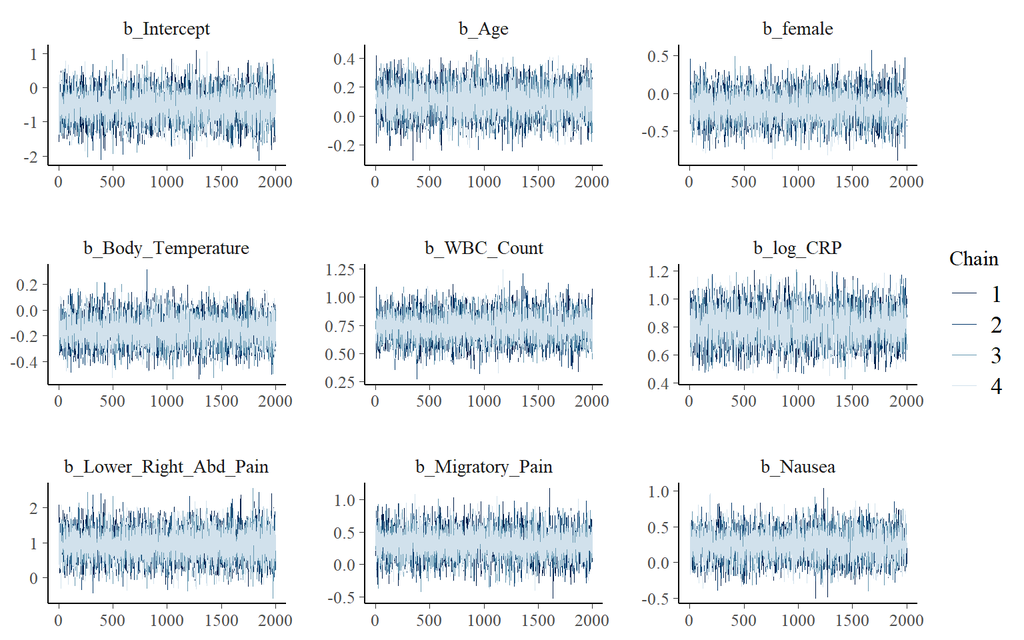

```r
# inspect every coefficient while reviewing the fit
bayesplot::mcmc_trace(
  as.array(fit),
  pars = diagnostic_table$variable
)
```

The four chains showed overlapping traces without obvious sustained drift or sticking. The largest $\widehat R$ across the intercept and slopes was 1.00081. Bulk effective sample sizes were at least 7,439, and tail effective sample sizes were at least 5,949. Monte Carlo standard errors for coefficient means were approximately 0.98-1.16% of their posterior standard deviations, indicating small simulation error relative to posterior uncertainty.

There were no divergent transitions or iterations reaching the maximum tree depth. E-BFMI ranged from 1.009 to 1.033 across chains. Together, these diagnostics supported using the posterior draws for inference, although they did not establish model adequacy or predictive accuracy.

## 5. Posterior Results and Interpretation

```r
auc_rank <- function(y, p) {
  n1 <- sum(y == 1)
  n0 <- sum(y == 0)

  if (!n1 || !n0) return(NA_real_)

  (sum(rank(p)[y == 1]) - n1 * (n1 + 1) / 2) / (n1 * n0)
}

metrics <- function(y, p, threshold = 0.5) {
  pos <- p > threshold

  c(
    AUC = auc_rank(y, p),
    Brier = mean((y - p)^2),
    Sensitivity = mean(pos[y == 1]),
    Specificity = mean(!pos[y == 0]),
    FN = sum(!pos & y == 1),
    FP = sum(pos & y == 0)
  )
}
```

```r
# calculate risks for the held-out patients without refitting
pdraw <- brms::posterior_epred(fit, newdata = test)
pbar <- colMeans(pdraw)

# summarize predictor associations
# the intercept is omitted because its exponential is baseline odds
coefs <- brms::fixef(fit, probs = c(.025, .975))
coefs <- coefs[rownames(coefs) != "Intercept", , drop = FALSE]
draws <- posterior::as_draws_df(fit)

coefficient_table <- data.frame(
  Term = rownames(coefs),
  Mean = coefs[, "Estimate"],
  Lower = coefs[, "Q2.5"],
  Upper = coefs[, "Q97.5"],
  OR = exp(coefs[, "Estimate"]),
  OR_low = exp(coefs[, "Q2.5"]),
  OR_high = exp(coefs[, "Q97.5"]),
  Pr_positive = vapply(
    rownames(coefs),
    function(v) mean(draws[[paste0("b_", v)]] > 0),
    numeric(1)
  ),
  row.names = NULL
)

# retain the training scales so we can interpret the coefficients
scale_table <- data.frame(
  Variable = continuous,
  Training_mean = unname(centers[continuous]),
  Training_SD = unname(scales[continuous])
)

# distinguish uncertainty about risk from the classification decision
patient_table <- data.frame(
  ID = test$id,
  Observed = test$y,
  Mean = pbar,
  Lower = apply(pdraw, 2, quantile, .025),
  Upper = apply(pdraw, 2, quantile, .975)
)

patient_table$Width <- patient_table$Upper - patient_table$Lower
patient_table$Predicted <- as.integer(patient_table$Mean > .5)

patient_table$Group <- factor(
  ifelse(
    patient_table$Lower > .5,
    "Interval above 0.50",
    ifelse(
      patient_table$Upper < .5,
      "Interval below 0.50",
      "Interval includes 0.50"
    )
  ),
  levels = c(
    "Interval below 0.50",
    "Interval includes 0.50",
    "Interval above 0.50"
  )
)

confidence_table <- as.data.frame(table(patient_table$Group))
names(confidence_table) <- c("Group", "N")

# describe the patients whose intervals include the threshold
uncertain <- patient_table[
  patient_table$Group == "Interval includes 0.50",
]

uncertainty_table <- data.frame(
  N = nrow(uncertain),
  Lowest_mean_risk = if (nrow(uncertain)) min(uncertain$Mean) else NA_real_,
  Highest_mean_risk = if (nrow(uncertain)) max(uncertain$Mean) else NA_real_,
  Median_interval_width = if (nrow(uncertain)) {
    median(uncertain$Width)
  } else {
    NA_real_
  }
)

# assess the primary model at the illustrative threshold
primary_performance <- data.frame(
  N = nrow(test),
  t(metrics(test$y, pbar, threshold = .5)),
  row.names = NULL
)

# compare with a constant prediction based on training prevalence
reference_brier <- mean((test$y - mean(train$y))^2)

confusion_table <- table(
  Recorded = factor(test$y, levels = 0:1),
  Predicted = factor(patient_table$Predicted, levels = 0:1)
)

# show observed proportions within fixed probability bins
calibration <- data.frame(y = test$y, p = pbar)
calibration$bin <- cut(
  calibration$p,
  breaks = seq(0, 1, .2),
  include.lowest = TRUE
)

calibration_table <- do.call(
  rbind,
  lapply(levels(calibration$bin), function(b) {
    z <- calibration[calibration$bin == b, ]
    if (!nrow(z)) return(NULL)

    ci <- binom.test(sum(z$y), nrow(z))$conf.int

    data.frame(
      Bin = b,
      N = nrow(z),
      Cases = sum(z$y),
      Predicted = mean(z$p),
      Observed = mean(z$y),
      Lower = ci[1],
      Upper = ci[2]
    )
  })
)

# select examples by predicted risk, not whether the prediction was correct
example_rows <- unique(c(
  which.min(patient_table$Mean),
  which.min(abs(patient_table$Mean - .5)),
  which.max(patient_table$Mean)
))

example_profiles <- test_raw[
  match(patient_table$ID[example_rows], test_raw$id),
  c(
    "Age", "female", "Body_Temperature", "WBC_Count",
    "Lower_Right_Abd_Pain", "Migratory_Pain", "Nausea"
  ),
  drop = FALSE
]

example_profiles$CRP <- expm1(
  test_raw$log_CRP[
    match(patient_table$ID[example_rows], test_raw$id)
  ]
)

example_table <- cbind(
  patient_table[
    example_rows,
    c("ID", "Observed", "Mean", "Lower", "Upper", "Group")
  ],
  example_profiles
)
```

White blood cell count and CRP showed clear positive associations with recorded appendicitis after adjustment for the other predictors. A one-standard-deviation increase in white blood cell count, corresponding to 5.249 on the recorded scale, had an odds ratio of 2.08 (95% credible interval 1.67-2.64). A one-standard-deviation increase in $\log(1+\mathrm{CRP})$, corresponding to 1.707 on that transformed scale, had an odds ratio of 2.25 (95% credible interval 1.79-2.86). Both posterior probabilities of a positive association exceeded 0.999. Right-lower-quadrant pain also showed a positive association, with an odds ratio of 2.55 (1.14-5.84) and posterior probability 0.989, although its magnitude was less precisely estimated. Direction remained less certain for the other predictors; their intervals included an odds ratio of one.

```r
tbl(
  coefficient_table,
  "Predictor associations. OR is the exponentiated posterior mean coefficient; intervals are 95% equal-tail credible intervals."
)
```

Predictor associations. OR is the exponentiated posterior mean coefficient; intervals are 95% equal-tail credible intervals.

| Term | Mean | Lower | Upper | OR | OR_low | OR_high | Pr_positive |
| --- | --- | --- | --- | --- | --- | --- | --- |
| Age | 0.104 | -0.095 | 0.303 | 1.110 | 0.910 | 1.354 | 0.840 |
| female | -0.169 | -0.547 | 0.204 | 0.844 | 0.579 | 1.226 | 0.187 |
| Body_Temperature | -0.155 | -0.368 | 0.058 | 0.856 | 0.692 | 1.059 | 0.083 |
| WBC_Count | 0.734 | 0.512 | 0.970 | 2.083 | 1.669 | 2.639 | 1.000 |
| log_CRP | 0.813 | 0.581 | 1.052 | 2.254 | 1.788 | 2.864 | 1.000 |
| Lower_Right_Abd_Pain | 0.934 | 0.134 | 1.765 | 2.545 | 1.143 | 5.840 | 0.989 |
| Migratory_Pain | 0.317 | -0.090 | 0.734 | 1.373 | 0.914 | 2.084 | 0.932 |
| Nausea | 0.245 | -0.124 | 0.613 | 1.278 | 0.883 | 1.846 | 0.900 |

```r
tbl(
  scale_table,
  "Training means and standard deviations before standardization; CRP is on the log(1 + CRP) scale."
)
```

Training means and standard deviations before standardization; CRP is on the log(1 + CRP) scale.

| Variable | Training_mean | Training_SD |
| --- | --- | --- |
| Age | 11.362 | 3.502 |
| Body_Temperature | 37.405 | 0.829 |
| WBC_Count | 12.612 | 5.249 |
| log_CRP | 2.207 | 1.707 |

Among the 153 held-out patients, 74 had 95% risk intervals entirely above 0.50, 45 entirely below, and 34 spanning the threshold. For those spanning it, posterior mean risks ranged from 0.321 to 0.673, with a median interval width of 0.250. Uncertainty therefore extended beyond patients whose mean risks were almost exactly 0.50.

```r
tbl(
  confidence_table,
  "Held-out patients grouped by the position of their 95% risk interval relative to 0.50."
)
```

Held-out patients grouped by the position of their 95% risk interval relative to 0.50.

| Group | N |
| --- | --- |
| Interval below 0.50 | 45 |
| Interval includes 0.50 | 34 |
| Interval above 0.50 | 74 |

```r
tbl(
  uncertainty_table,
  "Risk summaries for patients whose intervals include 0.50."
)
```

Risk summaries for patients whose intervals include 0.50.

| N | Lowest_mean_risk | Highest_mean_risk | Median_interval_width |
| --- | --- | --- | --- |
| 34 | 0.321 | 0.673 | 0.25 |

The individual examples illustrated why these uncertainty categories required careful interpretation. Patient 564, with high white blood cell count and CRP, had an estimated risk of 0.994 (0.983-0.999) and recorded appendicitis. Patient 4 had a risk of 0.498 (0.364-0.632), leaving the classification sensitive to parameter uncertainty. However, patient 431 had the lowest estimated risk, 0.142 (0.058-0.269), and still had recorded appendicitis. A risk interval below the threshold describes the model’s estimated probability, not certainty about the outcome.

```r
tbl(
  example_table,
  "Held-out patients with the lowest, closest-to-0.50, and highest posterior mean risks; predictors are shown before standardization. IDs refer to CSV row indices."
)
```

Held-out patients with the lowest, closest-to-0.50, and highest posterior mean risks; predictors are shown before standardization. IDs refer to CSV row indices.

| ID | Observed | Mean | Lower | Upper | Group | Age | female | Body_Temperature | WBC_Count | Lower_Right_Abd_Pain | Migratory_Pain | Nausea | CRP |
| --- | --- | --- | --- | --- | --- | --- | --- | --- | --- | --- | --- | --- | --- |
| 431 | 1 | 0.142 | 0.058 | 0.269 | Interval below 0.50 | 9.457 | 0 | 37.8 | 7.3 | 0 | 0 | 1 | 1 |
| 4 | 0 | 0.498 | 0.364 | 0.632 | Interval includes 0.50 | 16.370 | 1 | 36.0 | 11.4 | 1 | 1 | 1 | 0 |
| 564 | 1 | 0.994 | 0.983 | 0.999 | Interval above 0.50 | 16.590 | 0 | 37.7 | 37.7 | 1 | 0 | 1 | 71 |

Held-out AUC was 0.774, and the Brier score was 0.190, compared with 0.242 for a constant prediction based on training prevalence. At the 0.50 threshold, sensitivity was 0.789 and specificity was 0.635, with 19 false negatives and 23 false positives.

```r
tbl(
  primary_performance,
  "Primary-model performance on held-out patients at threshold 0.50."
)
```

Primary-model performance on held-out patients at threshold 0.50.

| N | AUC | Brier | Sensitivity | Specificity | FN | FP |
| --- | --- | --- | --- | --- | --- | --- |
| 153 | 0.774 | 0.19 | 0.789 | 0.635 | 19 | 23 |

```r
tbl(
  data.frame(Brier = reference_brier),
  "Held-out Brier score for a constant prediction equal to training prevalence."
)
```

Held-out Brier score for a constant prediction equal to training prevalence.

| Brier |
| --- |
| 0.242 |

```r
tbl(
  as.data.frame(confusion_table),
  "Recorded and predicted classifications; 1 indicates appendicitis."
)
```

Recorded and predicted classifications; 1 indicates appendicitis.

| Recorded | Predicted | Freq |
| --- | --- | --- |
| 0 | 0 | 40 |
| 1 | 0 | 19 |
| 0 | 1 | 23 |
| 1 | 1 | 71 |

Calibration was reasonably close in the higher-risk bins. In the lowest-risk bin, average predicted risk was 0.175, but three of five patients had recorded appendicitis. The small count produced a wide confidence interval, leaving the extent of underprediction uncertain. These findings raised concerns about using low predicted risks to rule out appendicitis. All risk intervals were conditional on the selected model and observed predictors; they did not account for uncertainty in labeling, exclusions, or model choice.

```r
tbl(
  calibration_table,
  "Held-out calibration with 95% binomial confidence intervals for observed proportions."
)
```

Held-out calibration with 95% binomial confidence intervals for observed proportions.

| Bin | N | Cases | Predicted | Observed | Lower | Upper |
| --- | --- | --- | --- | --- | --- | --- |
| [0,0.2] | 5 | 3 | 0.175 | 0.600 | 0.147 | 0.947 |
| (0.2,0.4] | 43 | 10 | 0.296 | 0.233 | 0.118 | 0.386 |
| (0.4,0.6] | 26 | 15 | 0.514 | 0.577 | 0.369 | 0.766 |
| (0.6,0.8] | 41 | 28 | 0.691 | 0.683 | 0.519 | 0.819 |
| (0.8,1] | 38 | 34 | 0.883 | 0.895 | 0.752 | 0.971 |

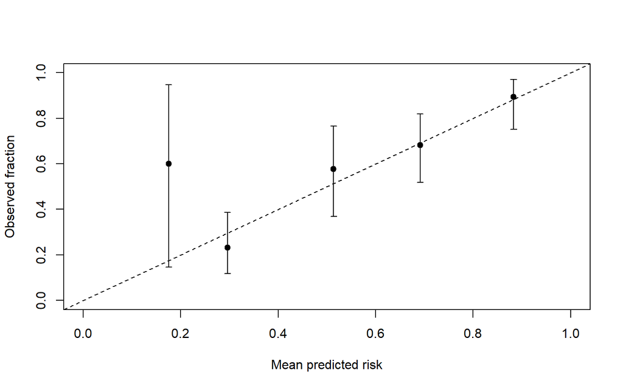

```r
with(calibration_table, {
  plot(
    Predicted, Observed,
    xlim = c(0, 1), ylim = c(0, 1),
    xlab = "Mean predicted risk",
    ylab = "Observed fraction",
    pch = 19
  )

  arrows(
    Predicted, Lower, Predicted, Upper,
    angle = 90, code = 3, length = .04
  )

  abline(0, 1, lty = 2)
})
```

## 6. Sensitivity Analysis and Model Checking

```r
# vary the slope priors while keeping the patients and scaling fixed
tight_fit <- fit_one(f, train, 0.5, "tight")
wide_fit <- fit_one(f, train, 2, "wide")

prior_fits <- list(
  Tighter = tight_fit,
  Primary = fit,
  Wider = wide_fit
)

sensitivity_table <- do.call(
  rbind,
  lapply(names(prior_fits), function(label) {
    m <- prior_fits[[label]]
    p <- colMeans(brms::posterior_epred(m, newdata = test))

    data.frame(
      Prior = label,
      t(metrics(test$y, p)),
      Mean_absolute_change = mean(abs(p - pbar)),
      Maximum_absolute_change = max(abs(p - pbar)),
      Decisions_changed = sum((p > .5) != (pbar > .5)),
      row.names = NULL
    )
  })
)

prior_coefficient_table <- do.call(
  rbind,
  lapply(names(prior_fits), function(label) {
    b <- brms::fixef(prior_fits[[label]], probs = c(.025, .975))
    b <- b[rownames(b) != "Intercept", , drop = FALSE]

    data.frame(
      Prior = label,
      Term = rownames(b),
      Mean = b[, "Estimate"],
      Lower = b[, "Q2.5"],
      Upper = b[, "Q97.5"],
      row.names = NULL
    )
  })
)
```

Predictions changed little across the three slope-prior scales, with held-out Brier scores ranging from 0.189 to 0.192. The tighter prior changed two classifications at 0.50; the wider prior changed none. WBC and log-CRP retained positive coefficient intervals throughout. Right-lower-quadrant pain was more sensitive: its posterior mean fell from 0.934 to 0.613 under the tighter prior, and its interval included zero. Predictive stability therefore did not imply equal stability in every association.

```r
tbl(
  sensitivity_table,
  "Prior sensitivity on identical held-out patients; probability changes are relative to the primary model."
)
```

Prior sensitivity on identical held-out patients; probability changes are relative to the primary model.

| Prior | AUC | Brier | Sensitivity | Specificity | FN | FP | Mean_absolute_change | Maximum_absolute_change | Decisions_changed |
| --- | --- | --- | --- | --- | --- | --- | --- | --- | --- |
| Tighter | 0.766 | 0.192 | 0.789 | 0.603 | 19 | 25 | 0.009 | 0.070 | 2 |
| Primary | 0.774 | 0.190 | 0.789 | 0.635 | 19 | 23 | 0.000 | 0.000 | 0 |
| Wider | 0.775 | 0.189 | 0.789 | 0.635 | 19 | 23 | 0.003 | 0.028 | 0 |

```r
tbl(
  prior_coefficient_table,
  "Coefficient sensitivity to alternative slope-prior scales; intervals are 95% credible intervals."
)
```

Coefficient sensitivity to alternative slope-prior scales; intervals are 95% credible intervals.

| Prior | Term | Mean | Lower | Upper |
| --- | --- | --- | --- | --- |
| Tighter | Age | 0.104 | -0.097 | 0.297 |
| Tighter | female | -0.161 | -0.522 | 0.200 |
| Tighter | Body_Temperature | -0.131 | -0.349 | 0.085 |
| Tighter | WBC_Count | 0.706 | 0.484 | 0.936 |
| Tighter | log_CRP | 0.780 | 0.553 | 1.010 |
| Tighter | Lower_Right_Abd_Pain | 0.613 | -0.050 | 1.270 |
| Tighter | Migratory_Pain | 0.291 | -0.105 | 0.691 |
| Tighter | Nausea | 0.215 | -0.131 | 0.565 |
| Primary | Age | 0.104 | -0.095 | 0.303 |
| Primary | female | -0.169 | -0.547 | 0.204 |
| Primary | Body_Temperature | -0.155 | -0.368 | 0.058 |
| Primary | WBC_Count | 0.734 | 0.512 | 0.970 |
| Primary | log_CRP | 0.813 | 0.581 | 1.052 |
| Primary | Lower_Right_Abd_Pain | 0.934 | 0.134 | 1.765 |
| Primary | Migratory_Pain | 0.317 | -0.090 | 0.734 |
| Primary | Nausea | 0.245 | -0.124 | 0.613 |
| Wider | Age | 0.104 | -0.104 | 0.314 |
| Wider | female | -0.175 | -0.546 | 0.206 |
| Wider | Body_Temperature | -0.163 | -0.387 | 0.061 |
| Wider | WBC_Count | 0.744 | 0.515 | 0.981 |
| Wider | log_CRP | 0.824 | 0.585 | 1.068 |
| Wider | Lower_Right_Abd_Pain | 1.071 | 0.193 | 1.945 |
| Wider | Migratory_Pain | 0.315 | -0.111 | 0.754 |
| Wider | Nausea | 0.254 | -0.126 | 0.636 |

```r
# add the flagged records to training, leaving the test patients unchanged
flagged_complete <- eligible[
  eligible$id %in% review_rows &
    complete.cases(eligible[, predictors]),
]

stopifnot(
  nrow(flagged_complete) == 2L,
  !any(flagged_complete$id %in% train_raw$id),
  !any(flagged_complete$id %in% test_raw$id)
)

# use the original training scales so the prior scales stay comparable
train_including_flagged <- transform_data(
  rbind(train_raw, flagged_complete)
)

included_fit <- fit_one(
  f,
  train_including_flagged,
  1,
  "including_flagged"
)

included_p <- colMeans(
  brms::posterior_epred(included_fit, newdata = test)
)

exclusion_table <- rbind(
  data.frame(
    Analysis = "Flagged records excluded",
    Training_N = nrow(train),
    Test_N = nrow(test),
    t(metrics(test$y, pbar)),
    Mean_absolute_change = 0,
    Maximum_absolute_change = 0,
    Decisions_changed = 0,
    row.names = NULL
  ),
  data.frame(
    Analysis = "Flagged records included in training",
    Training_N = nrow(train_including_flagged),
    Test_N = nrow(test),
    t(metrics(test$y, included_p)),
    Mean_absolute_change = mean(abs(included_p - pbar)),
    Maximum_absolute_change = max(abs(included_p - pbar)),
    Decisions_changed = sum((included_p > .5) != (pbar > .5)),
    row.names = NULL
  )
)

exclusion_fits <- list(
  Excluded = fit,
  Included = included_fit
)

exclusion_coefficient_table <- do.call(
  rbind,
  lapply(names(exclusion_fits), function(label) {
    b <- brms::fixef(exclusion_fits[[label]], probs = c(.025, .975))
    b <- b[rownames(b) != "Intercept", , drop = FALSE]

    data.frame(
      Analysis = label,
      Term = rownames(b),
      Mean = b[, "Estimate"],
      Lower = b[, "Q2.5"],
      Upper = b[, "Q97.5"],
      row.names = NULL
    )
  })
)
```

Including the two flagged records in training, with scaling and test patients unchanged, changed predicted probabilities by 0.008 on average and 0.029 at most. One classification changed; AUC and Brier score were unchanged at the reported precision. Findings were therefore stable to these exclusions, although measurement validity remained unresolved.

```r
tbl(
  exclusion_table,
  "Sensitivity to including the two flagged records in training; evaluation uses the original held-out patients."
)
```

Sensitivity to including the two flagged records in training; evaluation uses the original held-out patients.

| Analysis | Training_N | Test_N | AUC | Brier | Sensitivity | Specificity | FN | FP | Mean_absolute_change | Maximum_absolute_change | Decisions_changed |
| --- | --- | --- | --- | --- | --- | --- | --- | --- | --- | --- | --- |
| Flagged records excluded | 607 | 153 | 0.774 | 0.19 | 0.789 | 0.635 | 19 | 23 | 0.000 | 0.000 | 0 |
| Flagged records included in training | 609 | 153 | 0.774 | 0.19 | 0.789 | 0.619 | 19 | 24 | 0.008 | 0.029 | 1 |

```r
tbl(
  exclusion_coefficient_table,
  "Coefficient sensitivity to the data-quality exclusions, using unchanged predictor scaling."
)
```

Coefficient sensitivity to the data-quality exclusions, using unchanged predictor scaling.

| Analysis | Term | Mean | Lower | Upper |
| --- | --- | --- | --- | --- |
| Excluded | Age | 0.104 | -0.095 | 0.303 |
| Excluded | female | -0.169 | -0.547 | 0.204 |
| Excluded | Body_Temperature | -0.155 | -0.368 | 0.058 |
| Excluded | WBC_Count | 0.734 | 0.512 | 0.970 |
| Excluded | log_CRP | 0.813 | 0.581 | 1.052 |
| Excluded | Lower_Right_Abd_Pain | 0.934 | 0.134 | 1.765 |
| Excluded | Migratory_Pain | 0.317 | -0.090 | 0.734 |
| Excluded | Nausea | 0.245 | -0.124 | 0.613 |
| Included | Age | 0.097 | -0.104 | 0.298 |
| Included | female | -0.188 | -0.567 | 0.187 |
| Included | Body_Temperature | -0.094 | -0.285 | 0.100 |
| Included | WBC_Count | 0.733 | 0.506 | 0.969 |
| Included | log_CRP | 0.785 | 0.557 | 1.019 |
| Included | Lower_Right_Abd_Pain | 0.926 | 0.113 | 1.738 |
| Included | Migratory_Pain | 0.314 | -0.111 | 0.745 |
| Included | Nausea | 0.234 | -0.149 | 0.610 |

```r
# simulate outcomes at the observed training predictor values
set.seed(638)
yrep <- brms::posterior_predict(fit, ndraws = 1000)

# use the original ages to make the group definitions easier to read
ppc_groups <- list(
  All = rep(TRUE, nrow(train)),
  Female = train_raw$female == 1,
  Male = train_raw$female == 0,
  Under_12 = train_raw$Age < 12,
  Age_12_and_over = train_raw$Age >= 12
)

ppc_table <- do.call(
  rbind,
  lapply(names(ppc_groups), function(label) {
    i <- ppc_groups[[label]]
    if (!any(i)) return(NULL)

    rates <- rowMeans(yrep[, i, drop = FALSE])

    data.frame(
      Group = label,
      N = sum(i),
      Observed = mean(train$y[i]),
      Replicated_mean = mean(rates),
      Lower = unname(quantile(rates, .025)),
      Upper = unname(quantile(rates, .975))
    )
  })
)
```

Observed training proportions fell within the posterior predictive intervals overall and in each sex and age group. These checks revealed no obvious aggregate mismatch, but did not establish that the assumed linear effects were adequate or resolve the held-out calibration concerns in Section 5.

```r
tbl(
  ppc_table,
  "Training posterior predictive checks; intervals contain the central 95% of replicated proportions."
)
```

Training posterior predictive checks; intervals contain the central 95% of replicated proportions.

| Group | N | Observed | Replicated_mean | Lower | Upper |
| --- | --- | --- | --- | --- | --- |
| All | 607 | 0.588 | 0.587 | 0.537 | 0.633 |
| Female | 297 | 0.532 | 0.533 | 0.468 | 0.596 |
| Male | 310 | 0.642 | 0.639 | 0.574 | 0.706 |
| Under_12 | 335 | 0.606 | 0.612 | 0.552 | 0.675 |
| Age_12_and_over | 272 | 0.566 | 0.556 | 0.485 | 0.625 |

```r
# describe performance within the recorded management groups
# management was not used as a predictor
management_groups <- list(
  Conservative = which(test$surgical == 0),
  Surgical = which(test$surgical == 1),
  Missing_management = which(is.na(test$surgical))
)

surgical_performance <- do.call(
  rbind,
  lapply(names(management_groups), function(label) {
    i <- management_groups[[label]]
    if (!length(i)) return(NULL)

    scores <- metrics(test$y[i], pbar[i])

    # a subgroup may contain only one outcome class
    scores[is.nan(scores)] <- NA_real_

    data.frame(
      Management = label,
      N = length(i),
      Appendicitis = sum(test$y[i] == 1),
      No_appendicitis = sum(test$y[i] == 0),
      t(scores),
      row.names = NULL
    )
  })
)
```

Performance differed substantially by management group. Among conservatively managed patients, AUC was 0.580, and 13 of 28 recorded appendicitis cases were classified as negative at the 0.50 threshold. All 62 surgical patients had recorded appendicitis, preventing estimation of surgical-group AUC or specificity. These selected groups cannot provide an unbiased comparison of diagnostic accuracy.

```r
tbl(
  surgical_performance,
  "Primary-model performance by recorded management at threshold 0.50; unavailable metrics indicate an absent outcome class."
)
```

Primary-model performance by recorded management at threshold 0.50; unavailable metrics indicate an absent outcome class.

| Management | N | Appendicitis | No_appendicitis | AUC | Brier | Sensitivity | Specificity | FN | FP |
| --- | --- | --- | --- | --- | --- | --- | --- | --- | --- |
| Conservative | 91 | 28 | 63 | 0.58 | 0.256 | 0.536 | 0.635 | 13 | 23 |
| Surgical | 62 | 62 | 0 | NA | 0.092 | 0.903 | NA | 6 | 0 |

```r
# fit both models on the same ultrasound-complete patients
usvars <- c("Appendix_on_US", "Free_Fluids")

train_us <- train[
  complete.cases(train[, usvars]),
]

test_us <- test[
  complete.cases(test[, usvars]),
]

ultrasound_sample_table <- data.frame(
  Sample = c("Training", "Test"),
  Primary_N = c(nrow(train), nrow(test)),
  Ultrasound_complete_N = c(nrow(train_us), nrow(test_us))
)

# reset these so an old interactive fit cannot enter the comparison
fit_us_base <- NULL
fit_us <- NULL

if (
  nrow(train_us) > 30 &&
  nrow(test_us) > 10 &&
  length(unique(train_us$y)) == 2
) {
  fit_us_base <- fit_one(
    f,
    train_us,
    1,
    "us_matched_clinical"
  )

  fit_us <- fit_one(
    reformulate(c(predictors, usvars), response = "y"),
    train_us,
    1,
    "ultrasound"
  )

  us_fits <- list(
    Clinical = fit_us_base,
    With_ultrasound = fit_us
  )

  ultrasound_table <- do.call(
    rbind,
    lapply(names(us_fits), function(label) {
      p <- colMeans(
        brms::posterior_epred(us_fits[[label]], newdata = test_us)
      )

      scores <- metrics(test_us$y, p)
      scores[is.nan(scores)] <- NA_real_

      data.frame(
        Model = label,
        Training_N = nrow(train_us),
        Test_N = nrow(test_us),
        t(scores),
        row.names = NULL
      )
    })
  )
} else {
  ultrasound_table <- data.frame(
    Note = "Insufficient ultrasound-complete cases for this comparison"
  )
}
```

Adding ultrasound findings improved performance on the same 139 test patients: AUC increased from 0.768 to 0.872, Brier score fell from 0.192 to 0.137, and false negatives and false positives fell from 19 and 21 to 14 and 11. This improvement was observed in an ultrasound-complete subset using additional diagnostic information; labeling practices remained a limitation.

```r
tbl(
  ultrasound_sample_table,
  "Patients available for the matched ultrasound comparison."
)
```

Patients available for the matched ultrasound comparison.

| Sample | Primary_N | Ultrasound_complete_N |
| --- | --- | --- |
| Training | 607 | 568 |
| Test | 153 | 139 |

```r
tbl(
  ultrasound_table,
  "Clinical and ultrasound models evaluated on identical ultrasound-complete test patients."
)
```

Clinical and ultrasound models evaluated on identical ultrasound-complete test patients.

| Model | Training_N | Test_N | AUC | Brier | Sensitivity | Specificity | FN | FP |
| --- | --- | --- | --- | --- | --- | --- | --- | --- |
| Clinical | 568 | 139 | 0.768 | 0.192 | 0.768 | 0.632 | 19 | 21 |
| With_ultrasound | 568 | 139 | 0.872 | 0.137 | 0.829 | 0.807 | 14 | 11 |

```r
# check sampling reliability for every model used in these comparisons
all_fits <- list(
  Primary = fit,
  Tighter = tight_fit,
  Wider = wide_fit,
  Including_flagged = included_fit
)

if (!is.null(fit_us_base) && !is.null(fit_us)) {
  all_fits <- c(
    all_fits,
    list(
      US_matched_clinical = fit_us_base,
      Ultrasound = fit_us
    )
  )
}

all_diagnostics <- do.call(
  rbind,
  lapply(names(all_fits), function(label) {
    m <- all_fits[[label]]

    s <- posterior::summarise_draws(
      posterior::as_draws_array(m),
      "mean", "sd", "mcse_mean", "rhat", "ess_bulk", "ess_tail"
    )

    s <- s[grepl("^b_", s$variable), ]
    n <- brms::nuts_params(m)

    energy_rows <- n$Parameter == "energy__"
    energy_by_chain <- split(
      n$Value[energy_rows],
      n$Chain[energy_rows]
    )

    bfmi <- vapply(
      energy_by_chain,
      function(e) mean(diff(e)^2) / var(e),
      numeric(1)
    )

    data.frame(
      Model = label,
      Max_Rhat = max(s$rhat),
      Min_bulk_ESS = min(s$ess_bulk),
      Min_tail_ESS = min(s$ess_tail),
      Max_MCSE_over_SD = max(s$mcse_mean / s$sd),
      Divergences = sum(n$Value[n$Parameter == "divergent__"]),
      Treedepth_hits = sum(
        n$Value[n$Parameter == "treedepth__"] >= max_treedepth
      ),
      Min_E_BFMI = min(bfmi)
    )
  })
)
```

Across all six models, sampling diagnostics showed no divergences or treedepth hits, with maximum reported $\widehat R$ of 1.002.

```r
tbl(
  all_diagnostics,
  "Sampler diagnostics for the primary model and sensitivity comparisons."
)
```

Sampler diagnostics for the primary model and sensitivity comparisons.

| Model | Max_Rhat | Min_bulk_ESS | Min_tail_ESS | Max_MCSE_over_SD | Divergences | Treedepth_hits | Min_E_BFMI |
| --- | --- | --- | --- | --- | --- | --- | --- |
| Primary | 1.001 | 7438.681 | 5948.872 | 0.012 | 0 | 0 | 1.009 |
| Tighter | 1.002 | 7277.694 | 5557.104 | 0.012 | 0 | 0 | 0.954 |
| Wider | 1.001 | 6575.280 | 5539.670 | 0.012 | 0 | 0 | 0.959 |
| Including_flagged | 1.002 | 7975.274 | 5438.964 | 0.011 | 0 | 0 | 0.907 |
| US_matched_clinical | 1.001 | 7035.655 | 5523.666 | 0.012 | 0 | 0 | 0.955 |
| Ultrasound | 1.001 | 7111.140 | 5473.725 | 0.012 | 0 | 0 | 0.923 |

## 7. Alternative Analysis, Comparison, and Bayesian Justification

```r
# fit the same model using maximum likelihood
freq <- glm(
  f,
  data = train,
  family = binomial(link = "logit")
)

if (!isTRUE(freq$converged)) {
  stop("The frequentist fit did not converge, review it before comparing results")
}

freq_summary <- summary(freq)$coefficients

if (
  any(!is.finite(coef(freq))) ||
  any(!is.finite(freq_summary[, "Std. Error"]))
) {
  stop("The frequentist fit has unidentified or non-finite estimates, review it before comparing results")
}

pfreq <- as.numeric(
  predict(freq, newdata = test, type = "response")
)

# compare slopes on the same standardized predictor scales
# frequentist intervals use the normal approximation
slope_terms <- setdiff(rownames(freq_summary), "(Intercept)")
bayes_coefs <- brms::fixef(fit, probs = c(.025, .975))
z <- qnorm(.975)

coefficient_comparison <- data.frame(
  Term = slope_terms,
  Bayesian_mean = bayes_coefs[slope_terms, "Estimate"],
  Bayesian_lower = bayes_coefs[slope_terms, "Q2.5"],
  Bayesian_upper = bayes_coefs[slope_terms, "Q97.5"],
  Frequentist_estimate = freq_summary[slope_terms, "Estimate"],
  Frequentist_SE = freq_summary[slope_terms, "Std. Error"],
  Frequentist_lower =
    freq_summary[slope_terms, "Estimate"] -
    z * freq_summary[slope_terms, "Std. Error"],
  Frequentist_upper =
    freq_summary[slope_terms, "Estimate"] +
    z * freq_summary[slope_terms, "Std. Error"],
  row.names = NULL
)

# these are screening summaries, convergence alone does not rule out separation
frequentist_fit_checks <- data.frame(
  Converged = freq$converged,
  Iterations = freq$iter,
  Full_rank = freq$rank == ncol(model.matrix(freq)),
  Largest_absolute_slope =
    max(abs(freq_summary[slope_terms, "Estimate"])),
  Largest_slope_SE =
    max(freq_summary[slope_terms, "Std. Error"]),
  Minimum_fitted_probability = min(fitted(freq)),
  Maximum_fitted_probability = max(fitted(freq))
)
```

Frequentist logistic regression used the same predictors, transformations, training patients, and test patients as the Bayesian model. The fit converged in four iterations, with a full-rank design and no obvious coefficient instability in the screening summaries. WBC and log-CRP estimates were nearly identical between approaches. The largest difference concerned right-lower-quadrant pain: its frequentist coefficient was 1.097 (95% confidence interval 0.193-2.000), compared with a posterior mean of 0.934 (95% credible interval 0.134-1.765). This was consistent with the prior sensitivity observed in Section 6. The credible intervals described posterior uncertainty conditional on the model and priors; the confidence intervals used a repeated-sampling interpretation. Both supported similar conclusions about association direction.

```r
tbl(
  frequentist_fit_checks,
  "Frequentist fit checks; these summaries do not constitute a formal separation test."
)
```

Frequentist fit checks; these summaries do not constitute a formal separation test.

| Converged | Iterations | Full_rank | Largest_absolute_slope | Largest_slope_SE | Minimum_fitted_probability | Maximum_fitted_probability |
| --- | --- | --- | --- | --- | --- | --- |
| TRUE | 4 | TRUE | 1.097 | 0.461 | 0.061 | 0.989 |

```r
tbl(
  coefficient_comparison,
  "Adjusted coefficient comparison: Bayesian 95% equal-tail credible intervals and frequentist 95% Wald confidence intervals."
)
```

Adjusted coefficient comparison: Bayesian 95% equal-tail credible intervals and frequentist 95% Wald confidence intervals.

| Term | Bayesian_mean | Bayesian_lower | Bayesian_upper | Frequentist_estimate | Frequentist_SE | Frequentist_lower | Frequentist_upper |
| --- | --- | --- | --- | --- | --- | --- | --- |
| Age | 0.104 | -0.095 | 0.303 | 0.100 | 0.105 | -0.106 | 0.307 |
| female | -0.169 | -0.547 | 0.204 | -0.173 | 0.196 | -0.556 | 0.211 |
| Body_Temperature | -0.155 | -0.368 | 0.058 | -0.163 | 0.113 | -0.385 | 0.059 |
| WBC_Count | 0.734 | 0.512 | 0.970 | 0.733 | 0.119 | 0.500 | 0.966 |
| log_CRP | 0.813 | 0.581 | 1.052 | 0.811 | 0.123 | 0.570 | 1.051 |
| Lower_Right_Abd_Pain | 0.934 | 0.134 | 1.765 | 1.097 | 0.461 | 0.193 | 2.000 |
| Migratory_Pain | 0.317 | -0.090 | 0.734 | 0.310 | 0.218 | -0.118 | 0.738 |
| Nausea | 0.245 | -0.124 | 0.613 | 0.255 | 0.195 | -0.128 | 0.637 |

```r
# evaluate both models on the original held-out patients
performance <- rbind(
  data.frame(
    Model = "Bayesian",
    N = nrow(test),
    t(metrics(test$y, pbar)),
    row.names = NULL
  ),
  data.frame(
    Model = "Frequentist",
    N = nrow(test),
    t(metrics(test$y, pfreq)),
    row.names = NULL
  )
)

probability_comparison <- data.frame(
  Mean_absolute_difference = mean(abs(pbar - pfreq)),
  Maximum_absolute_difference = max(abs(pbar - pfreq)),
  Decisions_different = sum((pbar > .5) != (pfreq > .5))
)

# compare calibration using the same fixed bin boundaries
# patients can fall in different bins under the two models
model_probabilities <- list(
  Bayesian = pbar,
  Frequentist = pfreq
)

alternative_calibration <- do.call(
  rbind,
  lapply(names(model_probabilities), function(label) {
    p <- model_probabilities[[label]]
    bins <- cut(
      p,
      breaks = seq(0, 1, .2),
      include.lowest = TRUE
    )

    do.call(
      rbind,
      lapply(levels(bins), function(b) {
        i <- which(bins == b)
        if (!length(i)) return(NULL)

        ci <- binom.test(sum(test$y[i]), length(i))$conf.int

        data.frame(
          Model = label,
          Bin = b,
          N = length(i),
          Predicted = mean(p[i]),
          Observed = mean(test$y[i]),
          Lower = ci[1],
          Upper = ci[2]
        )
      })
    )
  })
)

# keep each patient's predictions paired during resampling
# the models stay fitted, so this only reflects test-sample variability
set.seed(639)

brier_difference <- replicate(2000, {
  i <- sample.int(nrow(test), size = nrow(test), replace = TRUE)

  mean(
    (test$y[i] - pbar[i])^2 -
      (test$y[i] - pfreq[i])^2
  )
})

brier_comparison <- data.frame(
  Difference = mean(
    (test$y - pbar)^2 - (test$y - pfreq)^2
  ),
  Lower = unname(quantile(brier_difference, .025)),
  Upper = unname(quantile(brier_difference, .975))
)
```

Held-out performance also differed little. Bayesian and frequentist AUCs were 0.774 and 0.777, with Brier scores of 0.190 and 0.189. Predicted probabilities differed by 0.005 on average and 0.040 at most. Only one classification differed at 0.50: both models produced 19 false negatives, while the Bayesian model produced 23 false positives compared with 24. Calibration patterns were similar, including uncertainty at the low-risk end.

The Bayesian-minus-frequentist Brier difference was 0.00095, with a 95% paired-bootstrap interval of -0.00021 to 0.00216. The small observed difference favored frequentist predictions, but the interval included zero. This comparison did not establish a predictive advantage for either approach. The bootstrap kept patient predictions paired and conditioned on the fitted models; it did not include variability from repeating training or selecting a different split.

```r
tbl(
  performance,
  "Held-out model performance at threshold 0.50."
)
```

Held-out model performance at threshold 0.50.

| Model | N | AUC | Brier | Sensitivity | Specificity | FN | FP |
| --- | --- | --- | --- | --- | --- | --- | --- |
| Bayesian | 153 | 0.774 | 0.190 | 0.789 | 0.635 | 19 | 23 |
| Frequentist | 153 | 0.777 | 0.189 | 0.789 | 0.619 | 19 | 24 |

```r
tbl(
  probability_comparison,
  "Differences between Bayesian and frequentist posterior-mean and fitted probabilities, respectively."
)
```

Differences between Bayesian and frequentist posterior-mean and fitted probabilities, respectively.

| Mean_absolute_difference | Maximum_absolute_difference | Decisions_different |
| --- | --- | --- |
| 0.005 | 0.04 | 1 |

```r
knitr::kable(
  brier_comparison,
  digits = 5,
  row.names = FALSE,
  caption = paste(
    "Bayesian minus frequentist Brier score, with a 95% paired",
    "patient-bootstrap percentile interval; negative values favor Bayesian predictions."
  )
)
```

Bayesian minus frequentist Brier score, with a 95% paired patient-bootstrap percentile interval; negative values favor Bayesian predictions.

| Difference | Lower | Upper |
| --- | --- | --- |
| 0.00095 | -0.00021 | 0.00216 |

```r
tbl(
  alternative_calibration,
  "Held-out calibration using fixed probability bins; intervals describe uncertainty in observed proportions."
)
```

Held-out calibration using fixed probability bins; intervals describe uncertainty in observed proportions.

| Model | Bin | N | Predicted | Observed | Lower | Upper |
| --- | --- | --- | --- | --- | --- | --- |
| Bayesian | [0,0.2] | 5 | 0.175 | 0.600 | 0.147 | 0.947 |
| Bayesian | (0.2,0.4] | 43 | 0.296 | 0.233 | 0.118 | 0.386 |
| Bayesian | (0.4,0.6] | 26 | 0.514 | 0.577 | 0.369 | 0.766 |
| Bayesian | (0.6,0.8] | 41 | 0.691 | 0.683 | 0.519 | 0.819 |
| Bayesian | (0.8,1] | 38 | 0.883 | 0.895 | 0.752 | 0.971 |
| Frequentist | [0,0.2] | 6 | 0.173 | 0.500 | 0.118 | 0.882 |
| Frequentist | (0.2,0.4] | 43 | 0.297 | 0.233 | 0.118 | 0.386 |
| Frequentist | (0.4,0.6] | 26 | 0.519 | 0.577 | 0.369 | 0.766 |
| Frequentist | (0.6,0.8] | 40 | 0.696 | 0.700 | 0.535 | 0.834 |
| Frequentist | (0.8,1] | 38 | 0.886 | 0.895 | 0.752 | 0.971 |

```r
# summarize binary classifications without treating them as probability estimates
classification_metrics <- function(y, predicted) {
  stopifnot(
    length(y) == length(predicted),
    length(y) > 0,
    !anyNA(y),
    !anyNA(predicted),
    all(y %in% 0:1),
    all(predicted %in% 0:1)
  )

  c(
    N = length(y),
    Accuracy = mean(predicted == y),
    Sensitivity = if (any(y == 1)) {
      mean(predicted[y == 1] == 1)
    } else {
      NA_real_
    },
    Specificity = if (any(y == 0)) {
      mean(predicted[y == 0] == 0)
    } else {
      NA_real_
    },
    FN = sum(predicted == 0 & y == 1),
    FP = sum(predicted == 1 & y == 0),
    TN = sum(predicted == 0 & y == 0),
    TP = sum(predicted == 1 & y == 1)
  )
}

# retain only the two unambiguous presumptive labels
benchmark <- eligible[!is.na(eligible$presumed), ]

benchmark_coverage <- data.frame(
  Eligible_N = nrow(eligible),
  Mapped_N = nrow(benchmark),
  Unmapped_N = sum(is.na(eligible$presumed)),
  Coverage_percent = 100 * nrow(benchmark) / nrow(eligible)
)

# show which labels were left out, including missing impressions
unmapped_labels <- raw$Diagnosis_Presumptive[
  eligible$id[is.na(eligible$presumed)]
]

unmapped_labels[is.na(unmapped_labels)] <- "(missing)"

unmapped_table <- as.data.frame(
  table(unmapped_labels),
  stringsAsFactors = FALSE
)
names(unmapped_table) <- c("Presumptive_label", "N")

if (nrow(benchmark) > 0) {
  benchmark_table <- data.frame(
    t(classification_metrics(benchmark$y, benchmark$presumed)),
    row.names = NULL
  )
} else {
  benchmark_table <- data.frame(
    Note = "No unambiguous presumptive labels available"
  )
}
```

Unambiguous presumptive diagnoses were available for 760 of 780 patients with recorded outcomes, giving 97.4% coverage. Agreement with the final diagnosis was 69.3%, with sensitivity 1.000 and specificity 0.251. There were 233 overcalls and no undercalls relative to the recorded diagnosis. Presumptive and final diagnoses therefore agreed more often than they disagreed, with all mapped disagreements representing overcalls.

```r
tbl(
  benchmark_coverage,
  "Coverage of unambiguous presumptive diagnoses among patients with recorded final diagnoses, before quality and predictor exclusions."
)
```

Coverage of unambiguous presumptive diagnoses among patients with recorded final diagnoses, before quality and predictor exclusions.

| Eligible_N | Mapped_N | Unmapped_N | Coverage_percent |
| --- | --- | --- | --- |
| 780 | 760 | 20 | 97.436 |

```r
tbl(
  unmapped_table,
  "Presumptive labels left unmapped."
)
```

Presumptive labels left unmapped.

| Presumptive_label | N |
| --- | --- |
| (missing) | 1 |
| abdominelle Adhäsionen, chron. Unterbauchbeschwerden mit Subileussymptomatik | 1 |
| Adhäsionen des Colon ascendens | 1 |
| Appendizitis, Lymphadenitis mesenterialis | 1 |
| Appendizitis/ Lymphadenitis mesenterialis | 1 |
| Bridenileus | 1 |
| chronische Appendizitis | 3 |
| chronische Bauchschmerzen | 2 |
| diabetische Ketoazidose, Myokarditis | 1 |
| Gastroenteritis | 3 |
| gedeckt perforierte Appendizitis | 1 |
| Ovarialtorsion | 1 |
| prolongierte Gastroenteritis | 1 |
| Sepsis mit Begleitappendizitis | 1 |
| Torsion der Adnexe | 1 |

```r
tbl(
  benchmark_table,
  "Agreement between unambiguous presumptive and final recorded diagnoses; FN denotes undercalls and FP denotes overcalls relative to the recorded diagnosis."
)
```

Agreement between unambiguous presumptive and final recorded diagnoses; FN denotes undercalls and FP denotes overcalls relative to the recorded diagnosis.

| N | Accuracy | Sensitivity | Specificity | FN | FP | TN | TP |
| --- | --- | --- | --- | --- | --- | --- | --- |
| 760 | 0.693 | 1 | 0.251 | 0 | 233 | 78 | 449 |

```r
# restrict all three comparisons to the same held-out patients
matched <- which(!is.na(test$presumed))

matched_coverage <- data.frame(
  Test_N = nrow(test),
  Mapped_N = length(matched),
  Unmapped_N = nrow(test) - length(matched),
  Coverage_percent = 100 * length(matched) / nrow(test)
)

if (length(matched) > 0) {
  matched_predictions <- list(
    Bayesian = as.integer(pbar[matched] > .5),
    Frequentist = as.integer(pfreq[matched] > .5),
    Presumptive = test$presumed[matched]
  )

  matched_performance <- do.call(
    rbind,
    lapply(names(matched_predictions), function(label) {
      data.frame(
        Method = label,
        t(classification_metrics(
          test$y[matched],
          matched_predictions[[label]]
        )),
        row.names = NULL
      )
    })
  )
} else {
  matched_performance <- data.frame(
    Note = "No mapped presumptive diagnoses among held-out patients"
  )
}
```

Among the same 151 mapped test patients, Bayesian accuracy was 72.2%, compared with 71.5% for frequentist predictions and 64.9% for presumptive diagnoses. However, presumptive diagnoses had no false negatives and 53 false positives, compared with 19 and 23 for the Bayesian model. Higher model accuracy therefore came with more missed recorded cases. The presumptive pattern was consistent with favoring sensitivity, but did not establish clinician intentions or a pediatric-specific strategy. Uncertainty about recording times and shared information between presumptive and final diagnoses also limited this comparison.

```r
tbl(
  matched_coverage,
  "Coverage of unambiguous presumptive diagnoses in the held-out sample."
)
```

Coverage of unambiguous presumptive diagnoses in the held-out sample.

| Test_N | Mapped_N | Unmapped_N | Coverage_percent |
| --- | --- | --- | --- |
| 153 | 151 | 2 | 98.693 |

```r
tbl(
  matched_performance,
  "Models and presumptive diagnoses compared on identical held-out patients; model classifications use threshold 0.50."
)
```

Models and presumptive diagnoses compared on identical held-out patients; model classifications use threshold 0.50.

| Method | N | Accuracy | Sensitivity | Specificity | FN | FP | TN | TP |
| --- | --- | --- | --- | --- | --- | --- | --- | --- |
| Bayesian | 151 | 0.722 | 0.787 | 0.629 | 19 | 23 | 39 | 70 |
| Frequentist | 151 | 0.715 | 0.787 | 0.613 | 19 | 24 | 38 | 70 |
| Presumptive | 151 | 0.649 | 1.000 | 0.145 | 0 | 53 | 9 | 89 |

The Bayesian contribution here was mainly interpretive: posterior draws connected uncertainty about associations and patient risks to the decision analysis. Regularization moderated the pain coefficient, but did not demonstrate better prediction. Frequentist methods can also quantify uncertainty and support cost-sensitive decisions. The practical benefit was a coherent framework for the questions posed, rather than superior held-out performance.

## 8. Innovation or Extension

```r
cost_ratios <- c(1, 2, 5, 10)

# use the existing patient intervals and keep the original patient order
stopifnot(identical(patient_table$ID, test$id))

risk_lower <- patient_table$Lower
risk_upper <- patient_table$Upper
baseline_positive <- pbar > .5

decision_table <- do.call(
  rbind,
  lapply(cost_ratios, function(r) {
    threshold <- 1 / (1 + r)
    positive <- pbar > threshold

    data.frame(
      Cost_ratio = r,
      Threshold = threshold,
      Positive = sum(positive),
      Changed_from_0.50 = sum(positive != baseline_positive),
      FN = sum(!positive & test$y == 1),
      FP = sum(positive & test$y == 0),
      Sensitivity = mean(positive[test$y == 1]),
      Specificity = mean(!positive[test$y == 0]),
      Realized_loss = mean(
        r * (!positive & test$y == 1) +
          (positive & test$y == 0)
      ),
      Posterior_expected_loss = mean(
        ifelse(positive, 1 - pbar, r * pbar)
      ),
      Intervals_including_threshold = sum(
        risk_lower <= threshold & risk_upper >= threshold
      )
    )
  })
)

# compare both rules under the same costs
# negative differences favor the cost-sensitive rule
decision_comparison <- do.call(
  rbind,
  lapply(cost_ratios, function(r) {
    threshold <- 1 / (1 + r)
    positive <- pbar > threshold

    baseline_realized <- mean(
      r * (!baseline_positive & test$y == 1) +
        (baseline_positive & test$y == 0)
    )

    cost_sensitive_realized <- mean(
      r * (!positive & test$y == 1) +
        (positive & test$y == 0)
    )

    baseline_expected <- mean(
      ifelse(baseline_positive, 1 - pbar, r * pbar)
    )

    cost_sensitive_expected <- mean(
      ifelse(positive, 1 - pbar, r * pbar)
    )

    data.frame(
      Cost_ratio = r,
      Baseline_realized_loss = baseline_realized,
      Cost_sensitive_realized_loss = cost_sensitive_realized,
      Realized_difference =
        cost_sensitive_realized - baseline_realized,
      Baseline_expected_loss = baseline_expected,
      Cost_sensitive_expected_loss = cost_sensitive_expected,
      Expected_difference =
        cost_sensitive_expected - baseline_expected
    )
  })
)

# identify patients newly classified as positive at each successive threshold
decision_changes <- do.call(
  rbind,
  lapply(seq_along(cost_ratios)[-1], function(k) {
    previous_threshold <- 1 / (1 + cost_ratios[k - 1])
    threshold <- 1 / (1 + cost_ratios[k])

    changed <- which(
      pbar > threshold & pbar <= previous_threshold
    )

    data.frame(
      Cost_ratio = cost_ratios[k],
      Previous_threshold = previous_threshold,
      Threshold = threshold,
      Newly_positive = length(changed),
      Recorded_appendicitis = sum(test$y[changed] == 1),
      Recorded_no_appendicitis = sum(test$y[changed] == 0),
      Lowest_mean_risk = if (length(changed)) {
        min(pbar[changed])
      } else {
        NA_real_
      },
      Highest_mean_risk = if (length(changed)) {
        max(pbar[changed])
      } else {
        NA_real_
      }
    )
  })
)
```

The comparison with presumptive diagnoses highlighted the tradeoff between false negatives and false positives. To examine this directly, false-positive cost was fixed at one and false-negative cost at $r$. With zero cost for correct classifications and posterior mean risk $\bar p_i$, posterior expected losses were $r\bar p_i$ for a negative classification and $1-\bar p_i$ for a positive classification. Minimizing expected loss therefore gave the rule

$$\text{classify positive if }\bar p_i>\frac{1}{1+r}.$$

Increasing the cost ratio from 1 to 2 lowered the threshold from 0.50 to 0.333. Twenty-two patients changed to positive classifications, including eight recorded appendicitis cases and 14 non-cases. False negatives fell from 19 to 11, while false positives increased from 23 to 37. At ratios of 5 and 10, false negatives fell to one and zero, but false positives reached 62 and 63. The ratio of 10 classified all 153 patients as positive.

Compared with retaining the 0.50 threshold under the same costs, realized loss per patient fell from 0.399 to 0.386 at ratio 2 and from 0.771 to 0.438 at ratio 5. Expected loss decreased by construction; improvement in realized loss was not guaranteed.

Risk intervals included the threshold for 34, 41, 18, and one patient across the four scenarios. These counts described parameter uncertainty; decisions used posterior mean risk. The illustrative costs omitted further assessment and treatment, so no preferred clinical threshold was established. Greater false-negative costs reduced missed recorded cases at the expense of more false positives.

```r
tbl(
  decision_table,
  "Classification consequences under illustrative false-negative to false-positive cost ratios; losses are per patient with false-positive cost fixed at one."
)
```

Classification consequences under illustrative false-negative to false-positive cost ratios; losses are per patient with false-positive cost fixed at one.

| Cost_ratio | Threshold | Positive | Changed_from_0.50 | FN | FP | Sensitivity | Specificity | Realized_loss | Posterior_expected_loss | Intervals_including_threshold |
| --- | --- | --- | --- | --- | --- | --- | --- | --- | --- | --- |
| 1 | 0.500 | 94 | 0 | 19 | 23 | 0.789 | 0.635 | 0.275 | 0.277 | 34 |
| 2 | 0.333 | 116 | 22 | 11 | 37 | 0.878 | 0.413 | 0.386 | 0.364 | 41 |
| 5 | 0.167 | 151 | 57 | 1 | 62 | 0.989 | 0.016 | 0.438 | 0.418 | 18 |
| 10 | 0.091 | 153 | 59 | 0 | 63 | 1.000 | 0.000 | 0.412 | 0.419 | 1 |

```r
tbl(
  decision_comparison,
  "Cost-sensitive versus 0.50 classifications evaluated under identical costs within each row; negative differences favor the cost-sensitive rule."
)
```

Cost-sensitive versus 0.50 classifications evaluated under identical costs within each row; negative differences favor the cost-sensitive rule.

| Cost_ratio | Baseline_realized_loss | Cost_sensitive_realized_loss | Realized_difference | Baseline_expected_loss | Cost_sensitive_expected_loss | Expected_difference |
| --- | --- | --- | --- | --- | --- | --- |
| 1 | 0.275 | 0.275 | 0.000 | 0.277 | 0.277 | 0.000 |
| 2 | 0.399 | 0.386 | -0.013 | 0.398 | 0.364 | -0.034 |
| 5 | 0.771 | 0.438 | -0.333 | 0.763 | 0.418 | -0.345 |
| 10 | 1.392 | 0.412 | -0.980 | 1.371 | 0.419 | -0.951 |

```r
tbl(
  decision_changes,
  "Patients newly classified as positive as the threshold decreases from the preceding scenario."
)
```

Patients newly classified as positive as the threshold decreases from the preceding scenario.

| Cost_ratio | Previous_threshold | Threshold | Newly_positive | Recorded_appendicitis | Recorded_no_appendicitis | Lowest_mean_risk | Highest_mean_risk |
| --- | --- | --- | --- | --- | --- | --- | --- |
| 2 | 0.500 | 0.333 | 22 | 8 | 14 | 0.335 | 0.498 |
| 5 | 0.333 | 0.167 | 35 | 10 | 25 | 0.181 | 0.333 |
| 10 | 0.167 | 0.091 | 2 | 1 | 1 | 0.142 | 0.165 |

## References

- Marcinkevičs, R., et al. (2023). *Regensburg Pediatric Appendicitis Dataset* (Version 1.01) [Data set]. Zenodo. https://doi.org/10.5281/zenodo.7669442. See also the [UCI dataset documentation](https://archive.ics.uci.edu/dataset/938/regensburg%2Bpediatric%2Bappendicitis).
- Stan Development Team. (n.d.). *Regression models*. Stan User’s Guide. https://mc-stan.org/docs/stan-users-guide/regression.html.
- Stan Development Team. (n.d.). *How to diagnose and resolve convergence problems*. https://mc-stan.org/learn-stan/diagnostics-warnings.html.
- Bürkner, P.-C. (n.d.). *Fit Bayesian generalized (non-)linear multivariate multilevel models*. brms reference documentation. https://paulbuerkner.com/brms/reference/brm.html.

## AI Use Statement

ChatGPT assisted with drafting, statistical explanations, and analysis code syntax. Source documentation and local data were inspected during drafting. Before submission, we ran and verified the analysis and reviewed model assumptions and citations. In effect, it provided guidance and a sort of backboard for us to talk our way through.

## Appendix: Reproducibility and Supporting Summaries

The analysis was implemented in R Markdown using the supplied `app_data.csv`. All preprocessing, model fitting, diagnostics, and comparisons are contained in `Project_Report.Rmd`; no external analysis script or data download is required.

Reproduction requires the CSV and report in the same directory, with model-dependent chunks enabled:

```r
rmarkdown::render(
  "Project_Report.Rmd",
  params = list(fit_models = TRUE)
)
```

Bayesian models were fitted through `brms` using the RStan backend. Other packages used were `knitr`, `rmarkdown`, `posterior`, and `bayesplot`. Model compilation requires a compatible C++ toolchain. Saved fits in `report_fits/` are reused when model inputs are unchanged and regenerated when model data, formulas, or priors change.

Random seeds were fixed, and continuous predictors were standardized using training-set means and standard deviations. Section 1 reports exclusions for questionable measurements and incomplete predictors. Section 5 reports the training means and standard deviations used for scaling. The software versions below document the environment used to render this report.

R and package versions used to render the report.

| Software | Version |
| --- | --- |
| R | 4.4.2 |
| brms | 2.23.0 |
| rstan | 2.32.7 |
| StanHeaders | 2.32.10 |
| knitr | 1.50 |
| rmarkdown | 2.29 |
| posterior | 1.7.0 |
| bayesplot | 1.16.0 |